# Assignment 1: Clustering

Harshit Gupta ~ hrgupta

February 07, 2019

First we will load the required libraries. We will make use of `NLP` , `tm` , `fpc` , `cluster` , `RColorBrewer` and `text2vec` libraries in R.

```r
library("NLP")
library("tm")
library("RColorBrewer")
library("fpc")
library("cluster")
library("text2vec")
```

We load all the 16 Accounts Tweets from the file and preprocess the data to remove punctuation, numbers, special characters and white spaces.

```r
cname <- file.path("C:\\Health-News-Tweets\\Health-Tweets")

tweetsData = VCorpus(DirSource(cname))

tweetsData <- tm_map(tweetsData, content_transformer(tolower))
tweetsData <- tm_map(tweetsData, content_transformer(function(x)gsub(x, pattern = "http.*\\W", replacement =  "")))
tweetsData <- tm_map(tweetsData, content_transformer(function(x)gsub(x, pattern = "/", replacement =  "")))
tweetsData <- tm_map(tweetsData, content_transformer(function(x)gsub(x, pattern = "\\|", replacement =  "")))
tweetsData <- tm_map(tweetsData, removePunctuation)
tweetsData <- tm_map(tweetsData, removeNumbers)
tweetsData <- tm_map(tweetsData, stripWhitespace)
```

Now we will plot the probabilities of the most frequent words for each account.

### 1. For Account: BBC Health

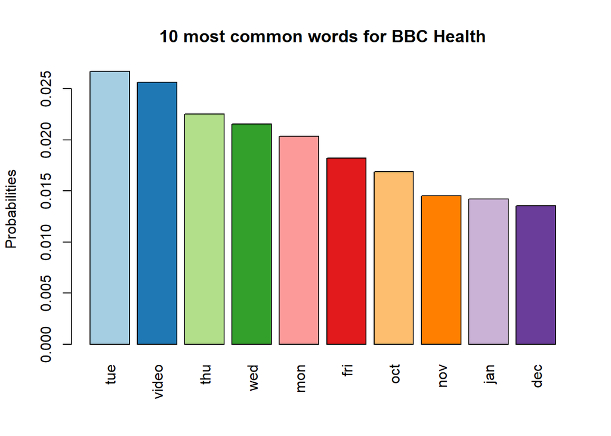

```r
dtm <- TermDocumentMatrix(tweetsData[1])
m <- as.matrix(dtm)
v <- sort(rowSums(m), decreasing = TRUE)
d <- data.frame(word = names(v), freq = v)

barplot(d[1:10,]$freq/sum(d$freq), las = 3, names.arg = d[1:10,]$word,
        col = brewer.pal(10, "Paired"), main ="10 most common words for BBC Health",
        ylab = "Probabilities")
```

### 2. For Account: CBC Health

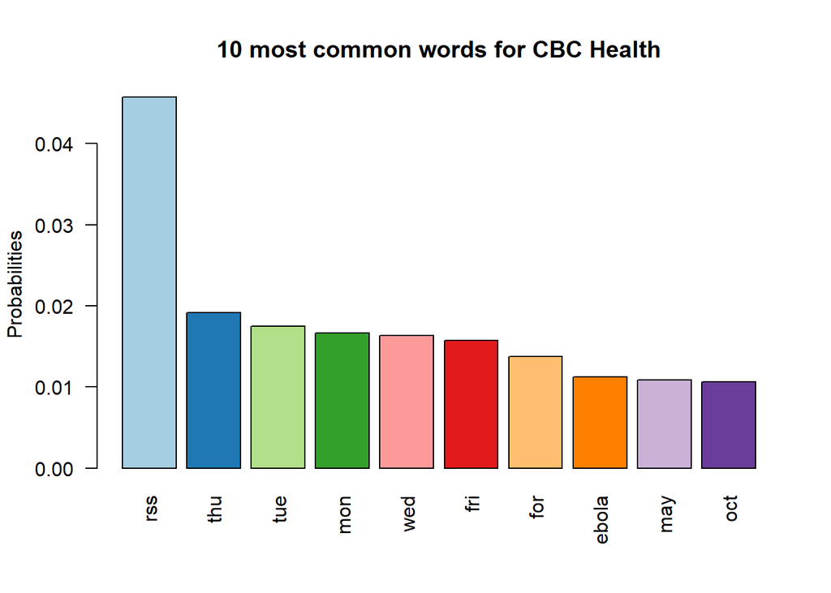

```r
dtm <- TermDocumentMatrix(tweetsData[2])
m <- as.matrix(dtm)
v <- sort(rowSums(m),decreasing=TRUE)
d <- data.frame(word = names(v),freq=v)

barplot(d[1:10,]$freq/sum(d$freq), las = 2, names.arg = d[1:10,]$word,
        col = brewer.pal(10, "Paired"), main ="10 most common words for CBC Health",
        ylab = "Probabilities")
```

### 3. For Account: CNN Health

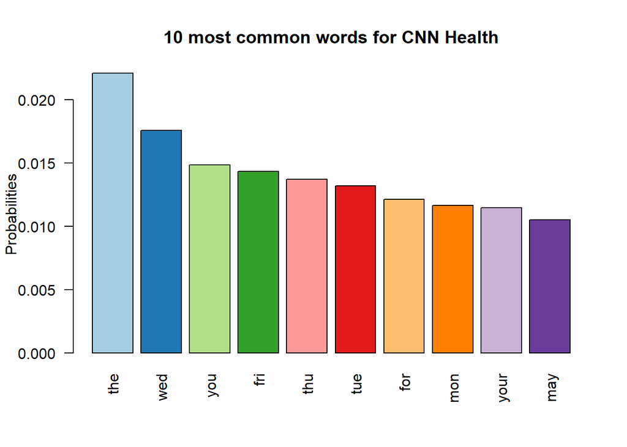

```r
dtm <- TermDocumentMatrix(tweetsData[3])
m <- as.matrix(dtm)
v <- sort(rowSums(m),decreasing = TRUE)
d <- data.frame(word = names(v),freq = v)

barplot(d[1:10,]$freq/sum(d$freq), las = 2, names.arg = d[1:10,]$word,
        col = brewer.pal(10, "Paired"), main ="10 most common words for CNN Health",
        ylab = "Probabilities")
```

### 4. For Account: Everyday Health

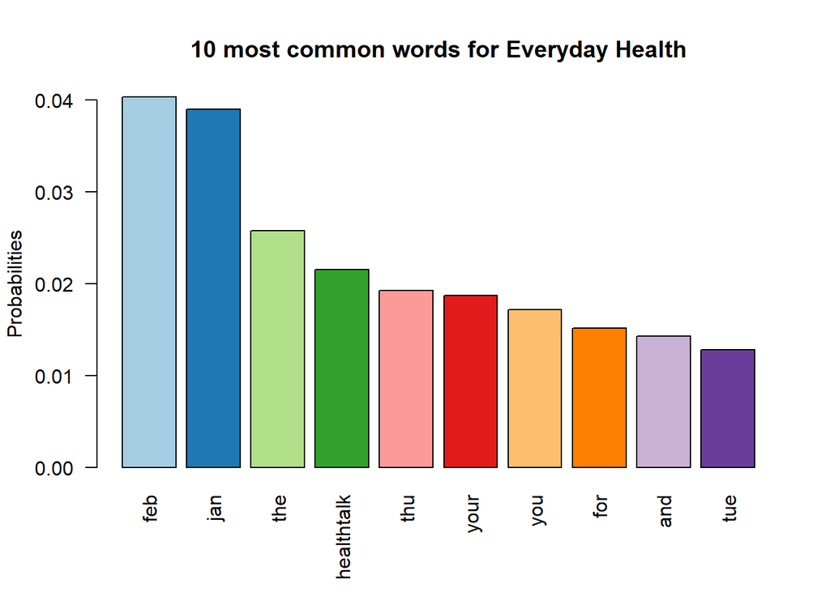

```r
dtm <- TermDocumentMatrix(tweetsData[4])
m <- as.matrix(dtm)
v <- sort(rowSums(m),decreasing=TRUE)
d <- data.frame(word = names(v),freq=v)

barplot(d[1:10,]$freq/sum(d$freq), las = 2, names.arg = d[1:10,]$word,
        col = brewer.pal(10, "Paired"), main ="10 most common words for Everyday Health",
        ylab = "Probabilities")
```

### 5. For Account: Fox News Health

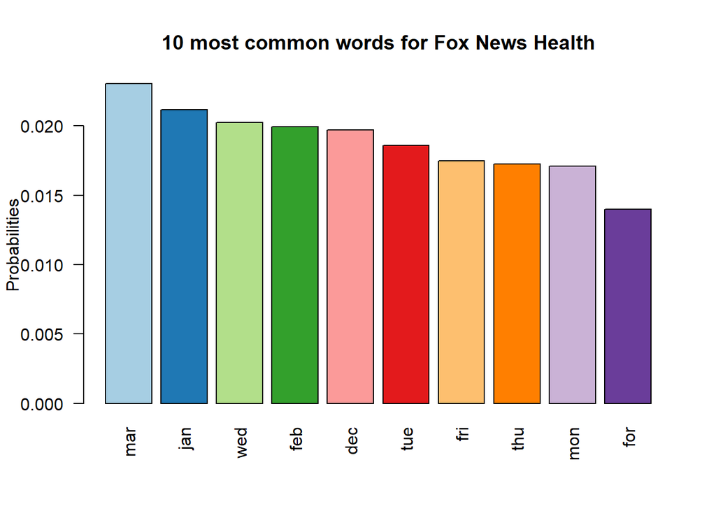

```r
dtm <- TermDocumentMatrix(tweetsData[5])
m <- as.matrix(dtm)
v <- sort(rowSums(m), decreasing = TRUE)
d <- data.frame(word = names(v),freq = v)

barplot(d[1:10,]$freq/sum(d$freq), las = 2, names.arg = d[1:10,]$word,
        col = brewer.pal(10, "Paired"), main ="10 most common words for Fox News Health",
        ylab = "Probabilities")
```

### 6. For Account: GDN Healthcare

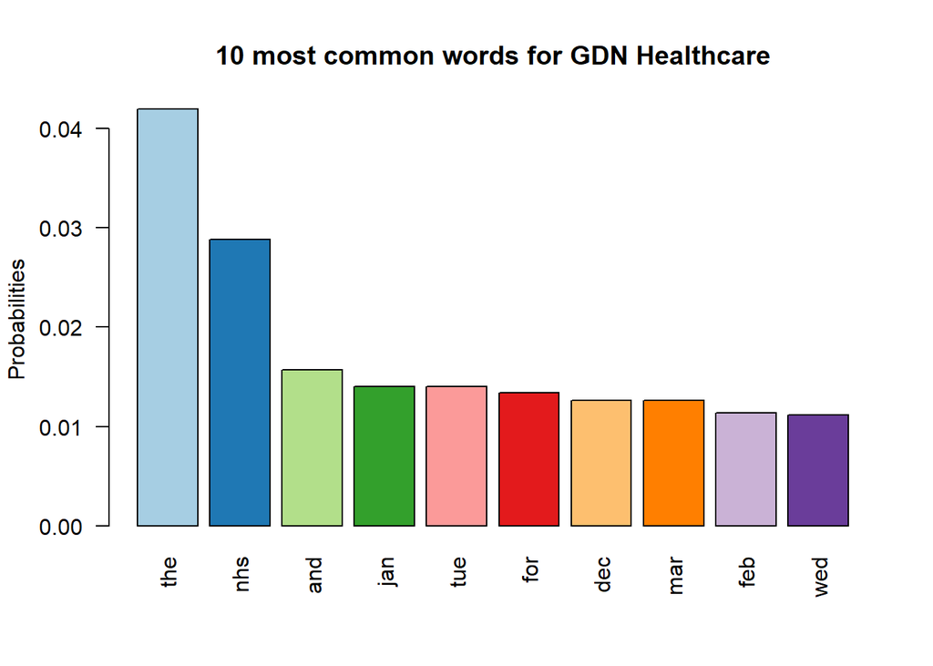

```r
dtm <- TermDocumentMatrix(tweetsData[6])
m <- as.matrix(dtm)
v <- sort(rowSums(m), decreasing = TRUE)
d <- data.frame(word = names(v), freq = v)

barplot(d[1:10,]$freq/sum(d$freq), las = 2, names.arg = d[1:10,]$word,
        col = brewer.pal(10, "Paired"), main ="10 most common words for GDN Healthcare",
        ylab = "Probabilities")
```

### 7. For Account: Good Health

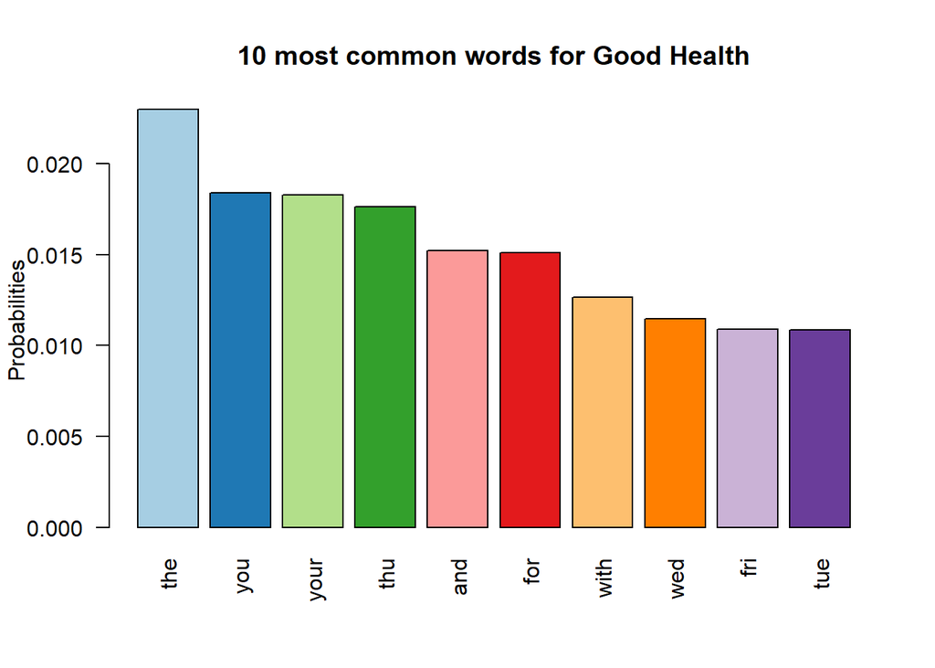

```r
dtm <- TermDocumentMatrix(tweetsData[7])
m <- as.matrix(dtm)
v <- sort(rowSums(m),decreasing=TRUE)
d <- data.frame(word = names(v),freq=v)

barplot(d[1:10,]$freq/sum(d$freq), las = 2, names.arg = d[1:10,]$word,
        col = brewer.pal(10, "Paired"), main ="10 most common words for Good Health",
        ylab = "Probabilities")
```

### 8. For Account: Kaiser Health News

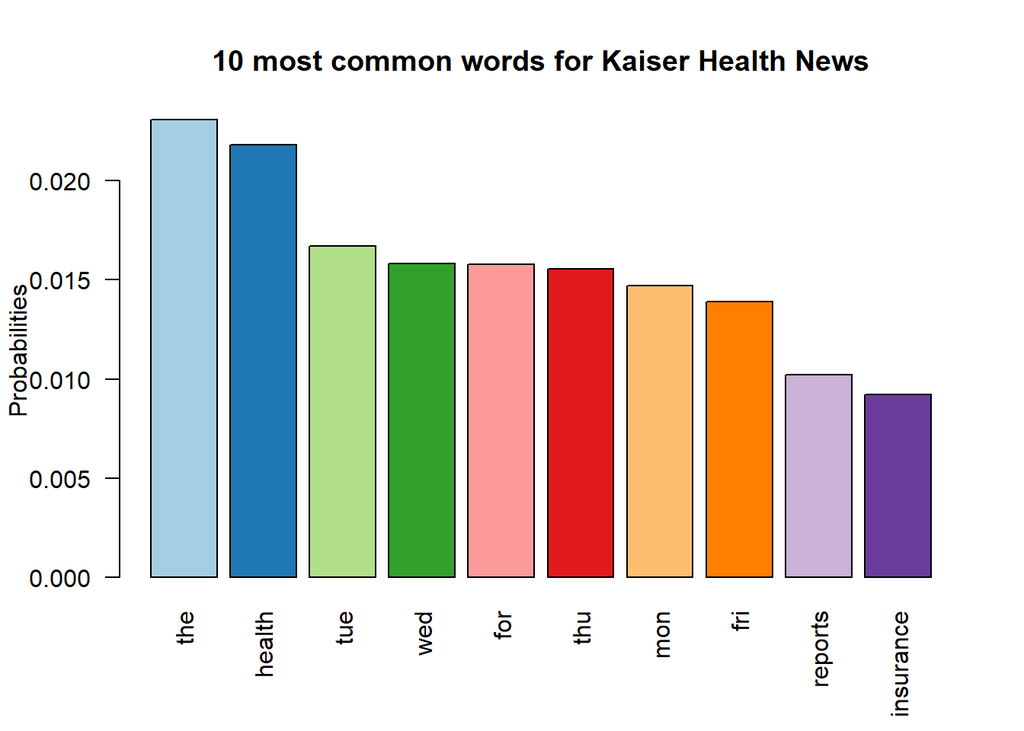

```r
dtm <- TermDocumentMatrix(tweetsData[8])
m <- as.matrix(dtm)
v <- sort(rowSums(m),decreasing=TRUE)
d <- data.frame(word = names(v),freq=v)

barplot(d[1:10,]$freq/sum(d$freq), las = 2, names.arg = d[1:10,]$word,
        col = brewer.pal(10, "Paired"), main ="10 most common words for Kaiser Health News",
        ylab = "Probabilities")
```

### 9. For Account: LA Times Health

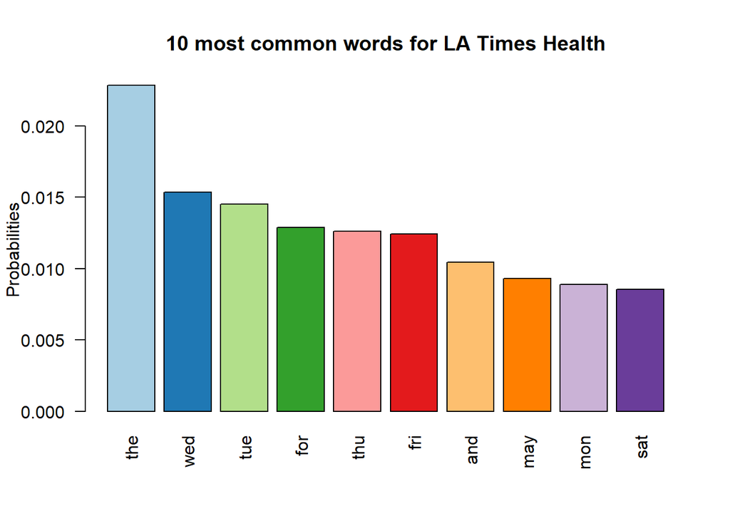

```r
dtm <- TermDocumentMatrix(tweetsData[9])
m <- as.matrix(dtm)
v <- sort(rowSums(m),decreasing=TRUE)
d <- data.frame(word = names(v),freq=v)

barplot(d[1:10,]$freq/sum(d$freq), las = 2, names.arg = d[1:10,]$word,
        col = brewer.pal(10, "Paired"), main ="10 most common words for LA Times Health",
        ylab = "Probabilities")
```

### 10. For Account: MSN Health News

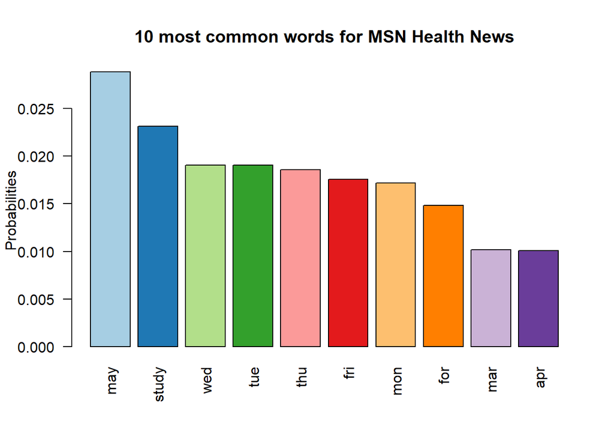

```r
dtm <- TermDocumentMatrix(tweetsData[10])
m <- as.matrix(dtm)
v <- sort(rowSums(m),decreasing=TRUE)
d <- data.frame(word = names(v),freq=v)

barplot(d[1:10,]$freq/sum(d$freq), las = 2, names.arg = d[1:10,]$word,
        col = brewer.pal(10, "Paired"), main ="10 most common words for MSN Health News",
        ylab = "Probabilities")
```

### 11. For Account: NBC Health

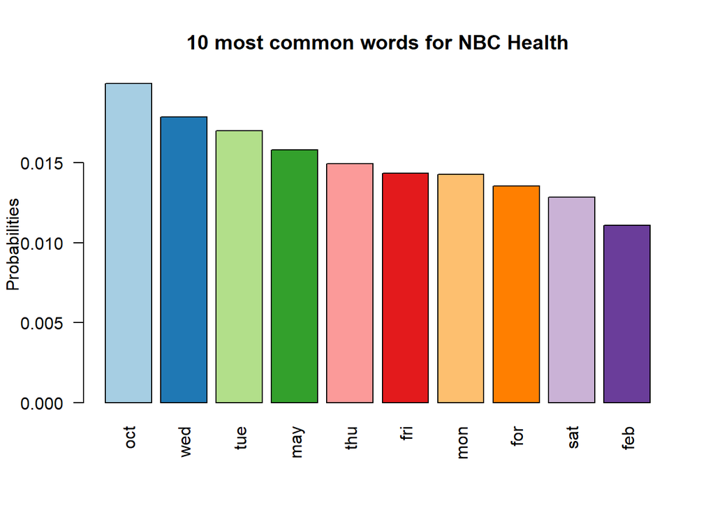

```r
dtm <- TermDocumentMatrix(tweetsData[11])
m <- as.matrix(dtm)
v <- sort(rowSums(m),decreasing=TRUE)
d <- data.frame(word = names(v),freq=v)

barplot(d[1:10,]$freq/sum(d$freq), las = 2, names.arg = d[1:10,]$word,
        col = brewer.pal(10, "Paired"), main ="10 most common words for NBC Health",
        ylab = "Probabilities")
```

### 12. For Account: NPR Health

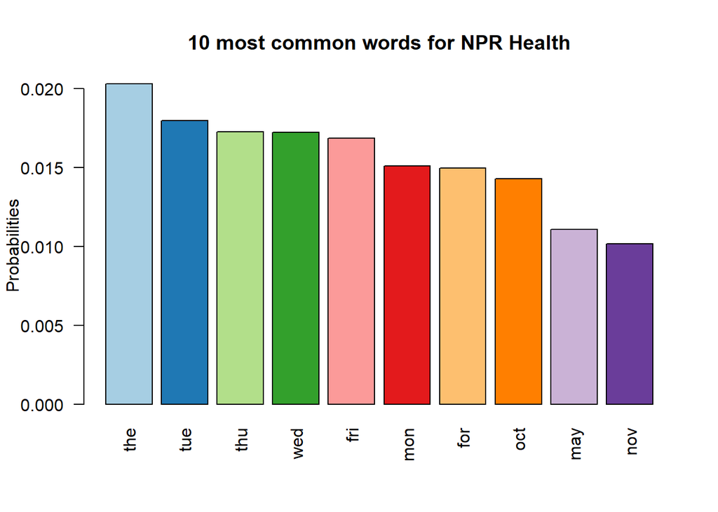

```r
dtm <- TermDocumentMatrix(tweetsData[12])
m <- as.matrix(dtm)
v <- sort(rowSums(m),decreasing=TRUE)
d <- data.frame(word = names(v),freq=v)

barplot(d[1:10,]$freq/sum(d$freq), las = 2, names.arg = d[1:10,]$word,
        col = brewer.pal(10, "Paired"), main ="10 most common words for NPR Health",
        ylab = "Probabilities")
```

### 13. For Account: NY Times Health

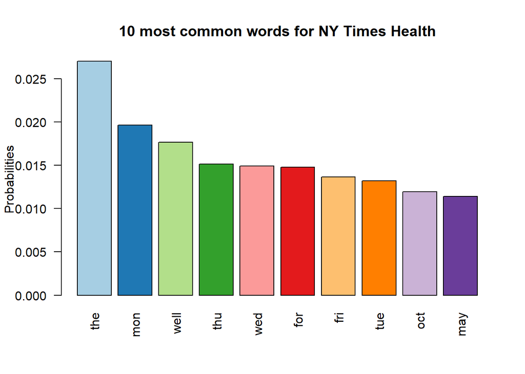

```r
dtm <- TermDocumentMatrix(tweetsData[13])
m <- as.matrix(dtm)
v <- sort(rowSums(m),decreasing=TRUE)
d <- data.frame(word = names(v),freq=v)

barplot(d[1:10,]$freq/sum(d$freq), las = 2, names.arg = d[1:10,]$word,
        col = brewer.pal(10, "Paired"), main ="10 most common words for NY Times Health",
        ylab = "Probabilities")
```

### 14. For Account: Reuters Health

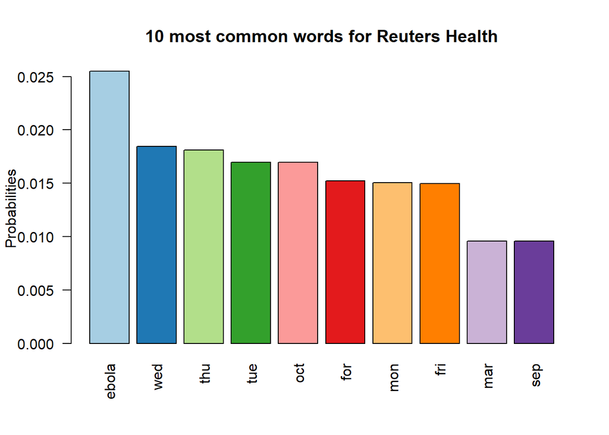

```r
dtm <- TermDocumentMatrix(tweetsData[14])
m <- as.matrix(dtm)
v <- sort(rowSums(m),decreasing=TRUE)
d <- data.frame(word = names(v),freq=v)

barplot(d[1:10,]$freq/sum(d$freq), las = 2, names.arg = d[1:10,]$word,
        col = brewer.pal(10, "Paired"), main ="10 most common words for Reuters Health",
        ylab = "Probabilities")
```

### 15. For Account: US News Health

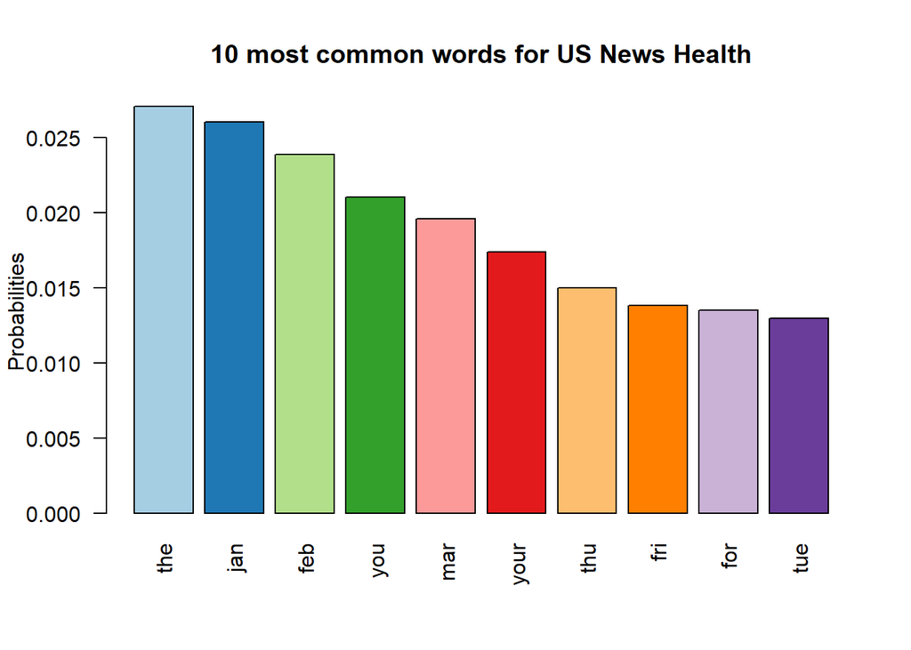

```r
dtm <- TermDocumentMatrix(tweetsData[15])
m <- as.matrix(dtm)
v <- sort(rowSums(m),decreasing=TRUE)
d <- data.frame(word = names(v),freq=v)

barplot(d[1:10,]$freq/sum(d$freq), las = 2, names.arg = d[1:10,]$word,
        col = brewer.pal(10, "Paired"), main ="10 most common words for US News Health",
        ylab = "Probabilities")
```

### 16. For Account: WSJ Health

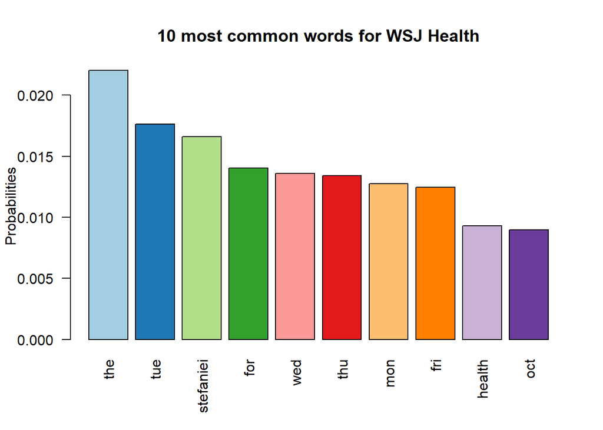

```r
dtm <- TermDocumentMatrix(tweetsData[16])
m <- as.matrix(dtm)
v <- sort(rowSums(m),decreasing=TRUE)
d <- data.frame(word = names(v),freq=v)

barplot(d[1:10,]$freq/sum(d$freq), las = 2, names.arg = d[1:10,]$word,
        col = brewer.pal(10, "Paired"), main ="10 most common words for WSJ Health",
        ylab = "Probabilities")
```

As can be seen from the above barcharts, the most common words in the tweets are the days of the week, months or most common english words ie. stopwords which are not related to heath. To imporve the results, we need to clean the dataset to remove unwanted data. We will make use of `stopwords()` function from the `tm` library to remove the most common stopwords and manually remove the other data we find to be unwanted.

```r
tweetsData <- tm_map(tweetsData, removeWords, stopwords("english"))
tweetsData <- tm_map(tweetsData, removeWords,c("jan","feb","mar","apr","may","jun","jul","aug","sep","oct","nov","dec"))
tweetsData <- tm_map(tweetsData, removeWords,c("mon","tue","wed","thu","fri","sat","sun","video","audio"))
```

We will now observe the effects of the additional cleaning on the tweets of BBC Health.

### 1. For Account: BBC Health

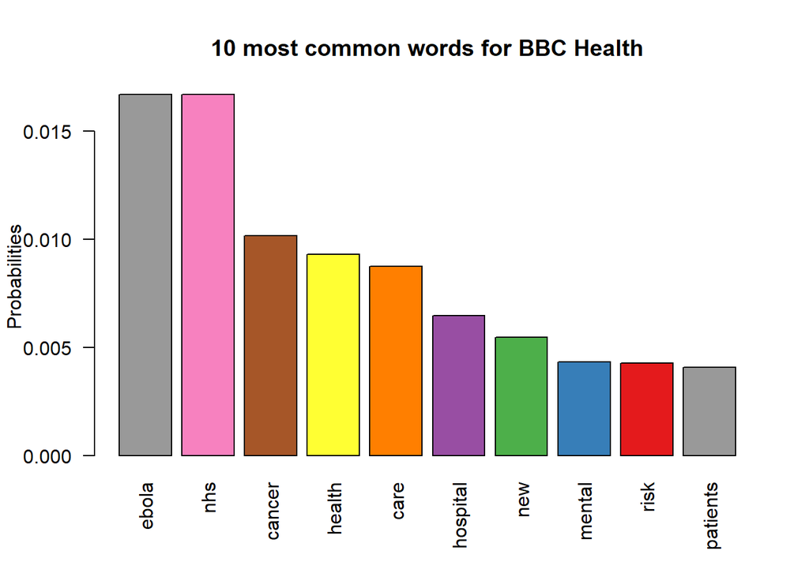

```r
dtm <- TermDocumentMatrix(tweetsData[1])
m <- as.matrix(dtm)
v <- sort(rowSums(m), decreasing = TRUE)
d <- data.frame(word = names(v), freq = v)

barplot(d[1:10,]$freq/sum(d$freq), las = 2, names.arg = d[1:10,]$word,
        col = rev(brewer.pal(10, "Set1")), main ="10 most common words for BBC Health",
        ylab = "Probabilities")
```

As can be seen from the above barchart, the most common words now are now related to health. We will now plot the **Top 10** words for the other accounts.

### 2. For Account: CBC Health

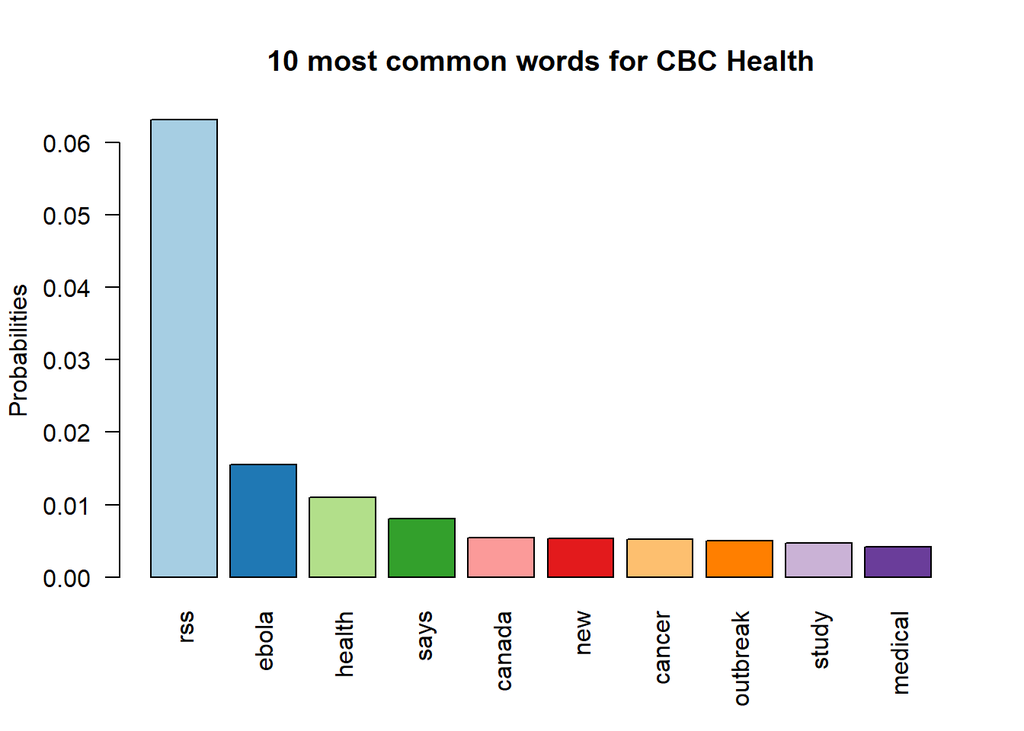

```r
dtm <- TermDocumentMatrix(tweetsData[2])
m <- as.matrix(dtm)
v <- sort(rowSums(m),decreasing=TRUE)
d <- data.frame(word = names(v),freq=v)

barplot(d[1:10,]$freq/sum(d$freq), las = 2, names.arg = d[1:10,]$word,
        col = brewer.pal(10, "Paired"), main ="10 most common words for CBC Health",
        ylab = "Probabilities")
```

### 3. For Account: CNN Health

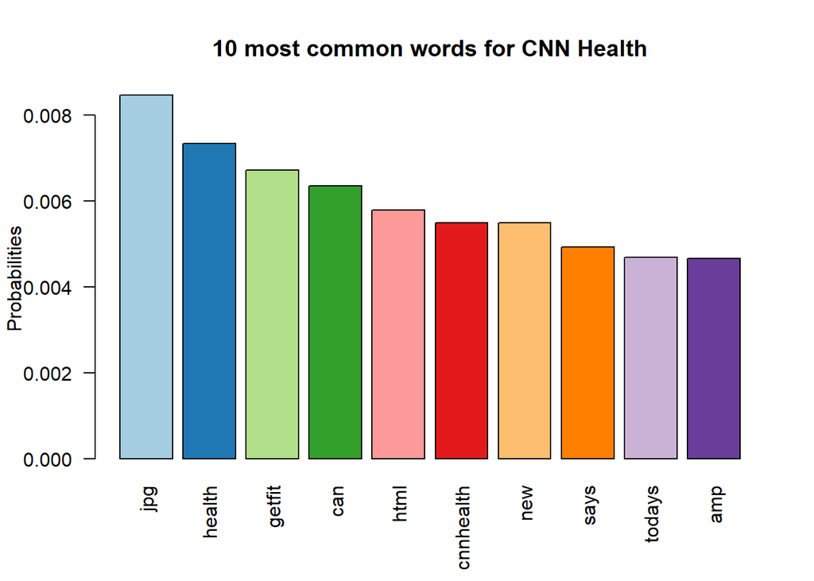

```r
dtm <- TermDocumentMatrix(tweetsData[3])
m <- as.matrix(dtm)
v <- sort(rowSums(m),decreasing = TRUE)
d <- data.frame(word = names(v),freq = v)

barplot(d[1:10,]$freq/sum(d$freq), las = 2, names.arg = d[1:10,]$word,
        col = brewer.pal(10, "Paired"), main ="10 most common words for CNN Health",
        ylab = "Probabilities")
```

### 4. For Account: Everyday Health

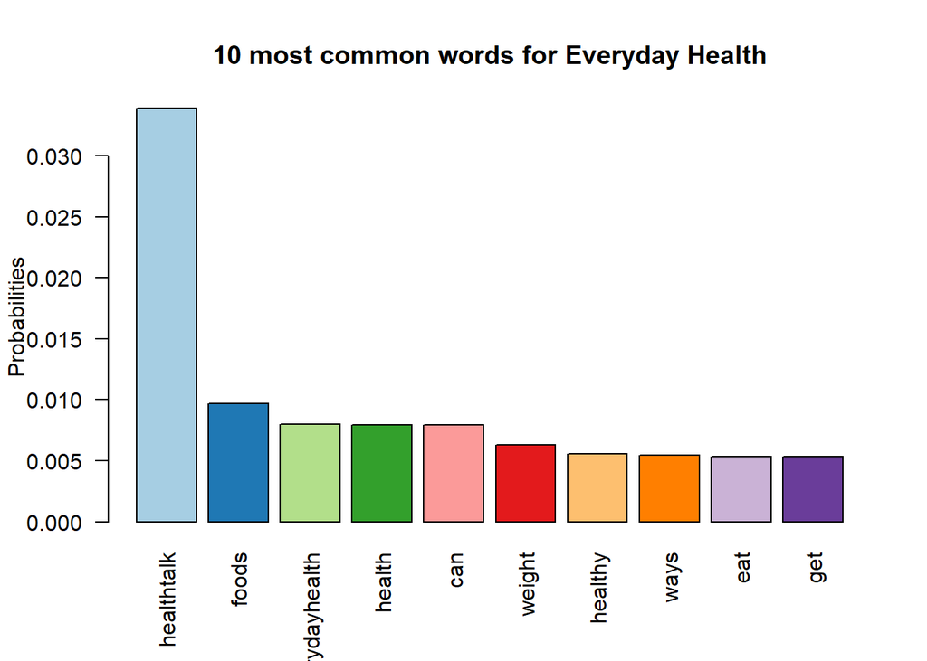

```r
dtm <- TermDocumentMatrix(tweetsData[4])
m <- as.matrix(dtm)
v <- sort(rowSums(m),decreasing=TRUE)
d <- data.frame(word = names(v),freq=v)

barplot(d[1:10,]$freq/sum(d$freq), las = 2, names.arg = d[1:10,]$word,
        col = brewer.pal(10, "Paired"), main ="10 most common words for Everyday Health",
        ylab = "Probabilities")
```

### 5. For Account: Fox News Health

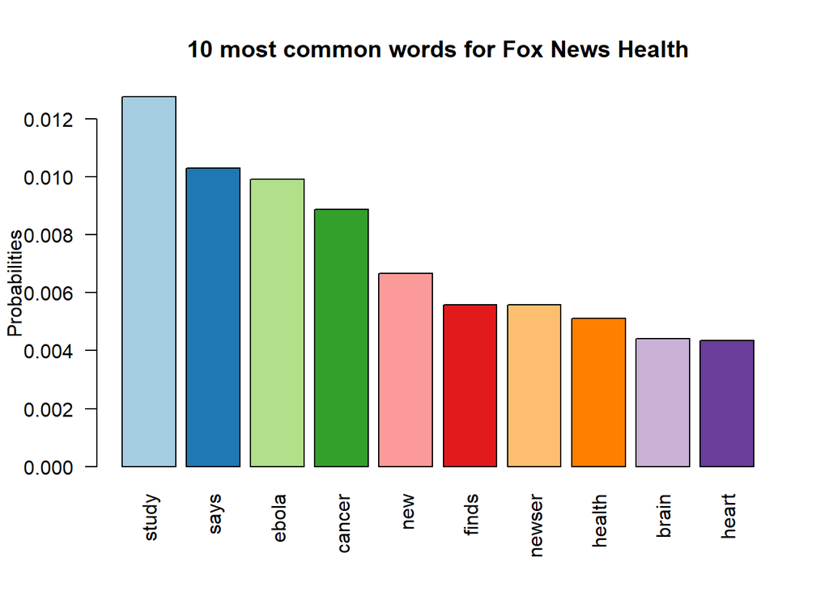

```r
dtm <- TermDocumentMatrix(tweetsData[5])
m <- as.matrix(dtm)
v <- sort(rowSums(m), decreasing = TRUE)
d <- data.frame(word = names(v),freq = v)

barplot(d[1:10,]$freq/sum(d$freq), las = 2, names.arg = d[1:10,]$word,
        col = brewer.pal(10, "Paired"), main ="10 most common words for Fox News Health",
        ylab = "Probabilities")
```

### 6. For Account: GDN Healthcare

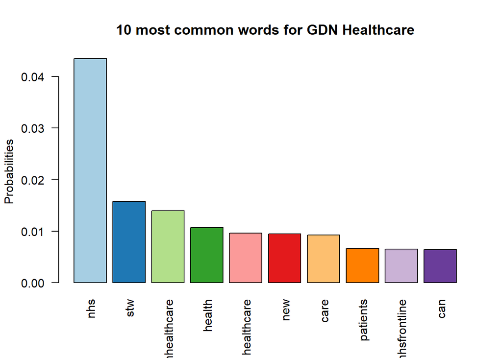

```r
dtm <- TermDocumentMatrix(tweetsData[6])
m <- as.matrix(dtm)
v <- sort(rowSums(m), decreasing = TRUE)
d <- data.frame(word = names(v), freq = v)

barplot(d[1:10,]$freq/sum(d$freq), las = 2, names.arg = d[1:10,]$word,
        col = brewer.pal(10, "Paired"), main ="10 most common words for GDN Healthcare",
        ylab = "Probabilities")
```

### 7. For Account: Good Health

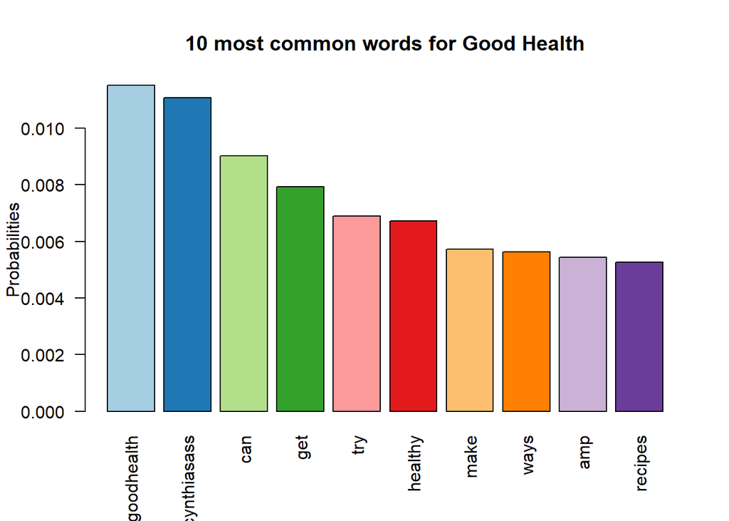

```r
dtm <- TermDocumentMatrix(tweetsData[7])
m <- as.matrix(dtm)
v <- sort(rowSums(m),decreasing=TRUE)
d <- data.frame(word = names(v),freq=v)

barplot(d[1:10,]$freq/sum(d$freq), las = 2, names.arg = d[1:10,]$word,
        col = brewer.pal(10, "Paired"), main ="10 most common words for Good Health",
        ylab = "Probabilities")
```

### 8. For Account: Kaiser Health News

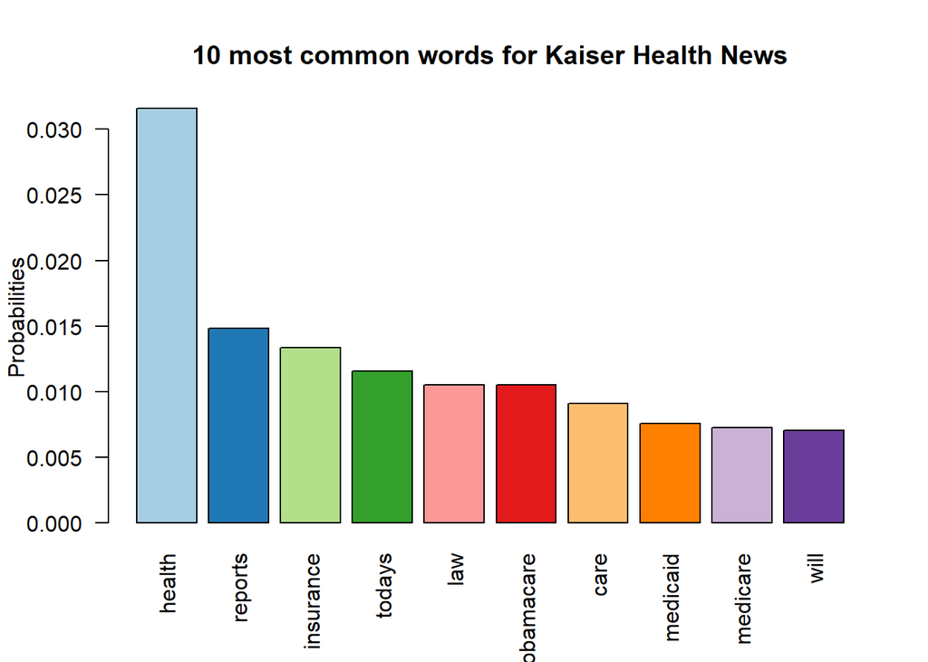

```r
dtm <- TermDocumentMatrix(tweetsData[8])
m <- as.matrix(dtm)
v <- sort(rowSums(m),decreasing=TRUE)
d <- data.frame(word = names(v),freq=v)

barplot(d[1:10,]$freq/sum(d$freq), las = 2, names.arg = d[1:10,]$word,
        col = brewer.pal(10, "Paired"), main ="10 most common words for Kaiser Health News",
        ylab = "Probabilities")
```

### 9. For Account: LA Times Health

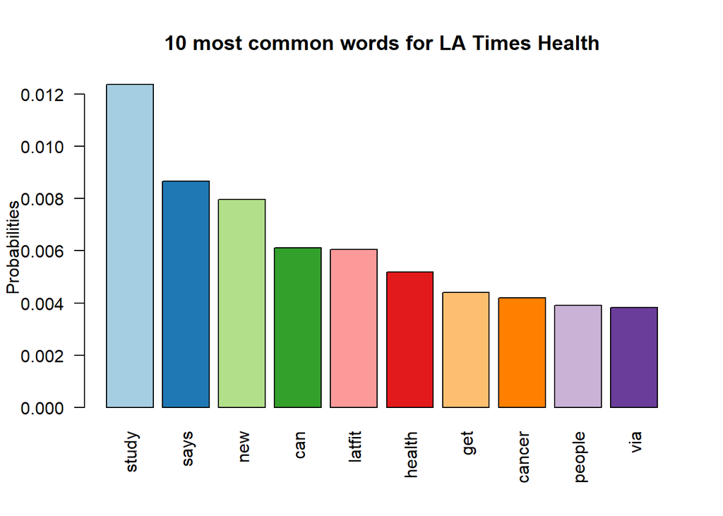

```r
dtm <- TermDocumentMatrix(tweetsData[9])
m <- as.matrix(dtm)
v <- sort(rowSums(m),decreasing=TRUE)
d <- data.frame(word = names(v),freq=v)

barplot(d[1:10,]$freq/sum(d$freq), las = 2, names.arg = d[1:10,]$word,
        col = brewer.pal(10, "Paired"), main ="10 most common words for LA Times Health",
        ylab = "Probabilities")
```

### 10. For Account: MSN Health News

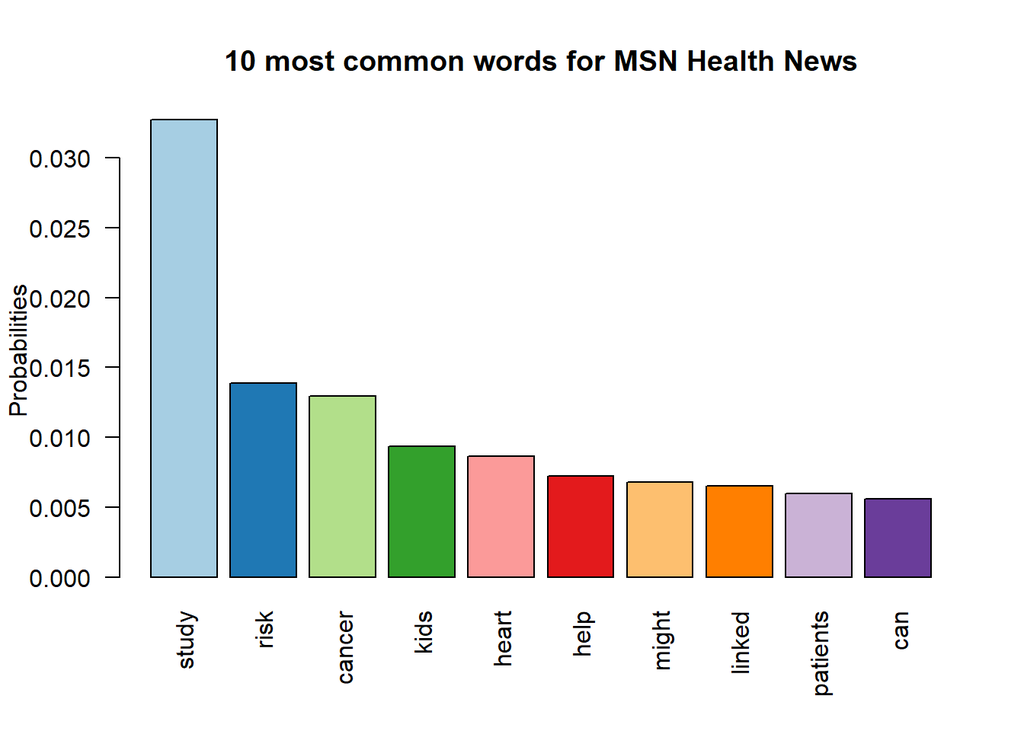

```r
dtm <- TermDocumentMatrix(tweetsData[10])
m <- as.matrix(dtm)
v <- sort(rowSums(m),decreasing=TRUE)
d <- data.frame(word = names(v),freq=v)

barplot(d[1:10,]$freq/sum(d$freq), las = 2, names.arg = d[1:10,]$word,
        col = brewer.pal(10, "Paired"), main ="10 most common words for MSN Health News",
        ylab = "Probabilities")
```

### 11. For Account: NBC Health

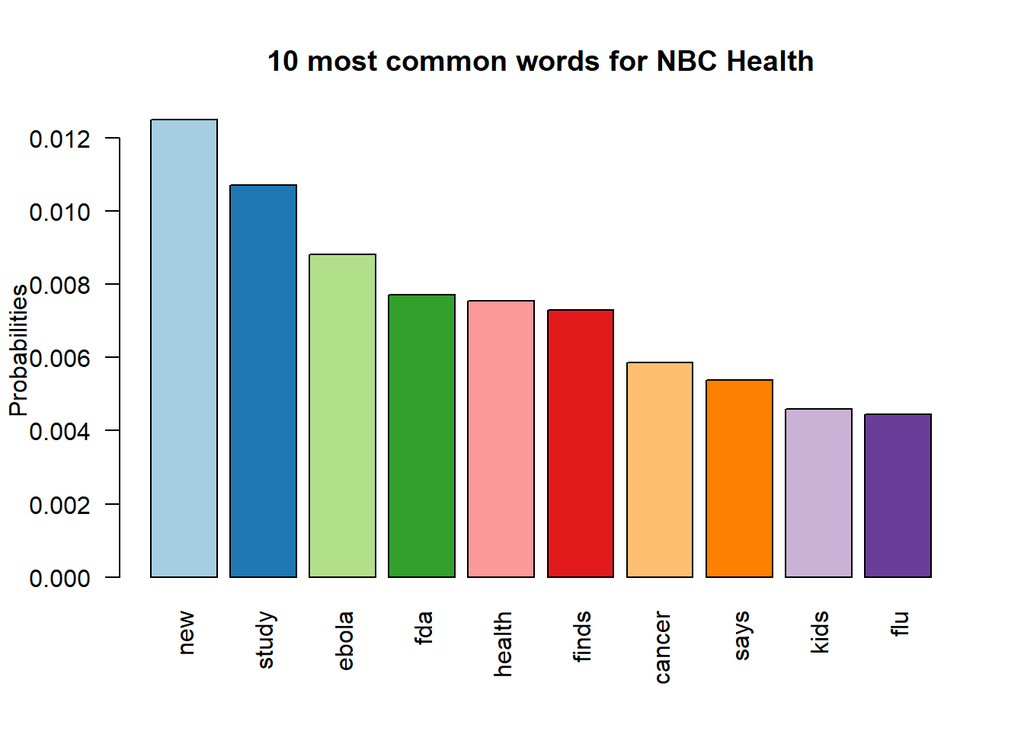

```r
dtm <- TermDocumentMatrix(tweetsData[11])
m <- as.matrix(dtm)
v <- sort(rowSums(m),decreasing=TRUE)
d <- data.frame(word = names(v),freq=v)

barplot(d[1:10,]$freq/sum(d$freq), las = 2, names.arg = d[1:10,]$word,
        col = brewer.pal(10, "Paired"), main ="10 most common words for NBC Health",
        ylab = "Probabilities")
```

### 12. For Account: NPR Health

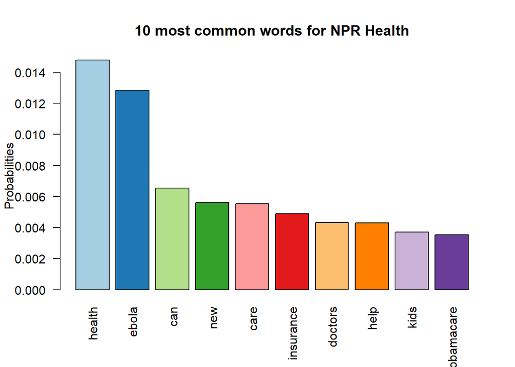

```r
dtm <- TermDocumentMatrix(tweetsData[12])
m <- as.matrix(dtm)
v <- sort(rowSums(m),decreasing=TRUE)
d <- data.frame(word = names(v),freq=v)

barplot(d[1:10,]$freq/sum(d$freq), las = 2, names.arg = d[1:10,]$word,
        col = brewer.pal(10, "Paired"), main ="10 most common words for NPR Health",
        ylab = "Probabilities")
```